# LendingClub

Xiwei Huang

2017/04/28

*Description: Lending Club is a peer-to-peer online lending platform, where consumers and small business owners lower the cost of their credit and enjoy a better experience than traditional bank lending, and investors earn attractive risk-adjusted returns. In this project, I will present and explore the data provided by Lending Club. Then I will use these data to predict whether a new borrower’s application will be approved.*

*The data is provided by Lending Club. It consists in 7 files (4 files for approved loan data and 3 files for declined loan data) updated every quarter on the same day as the quarterly results of the company are released. The information available for each loan consists of all the details of the loans at the time of their issuance as well as more information relative to the latest status of loan such as how much principal has been paid so far, how much interest, if the loan was fully paid or defaulted, or if the borrower is late on payments etc.*

**Prediction: Approve vs Reject** In this part, I will use these data to predict whether a new borrower’s application will be approved. Because there are only few variables in declined loan data, I select 4 variables (loan amount, score, debt to income rate and employment length) to make the prediction.

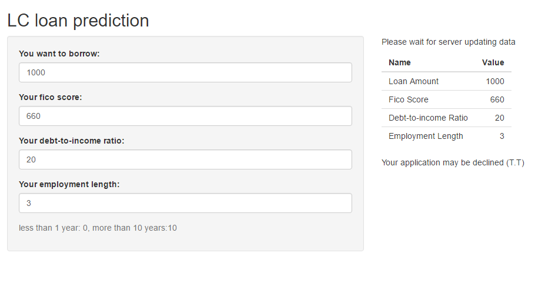

*load data, save the data to RData, accelerate the speed*

```r
setwd("E:/Master/EST 508/Projects/LendingClub")
load("approved.RData")
load("rejected.RData")
```

*select the variables we want to predict*

```r
#select variables(amount,score,dti,employment)
rej <- rejected[,c("amount","score","dti","employment")]
app <- approved[,c("amount","score","dti","employment")]
```

*deal with NA data and score == 0 data*

```r
rej <- na.omit(rej)
rej <- subset(rej, score!=0)
app <- na.omit(app)
app <- subset(app, score!=0)
```

*add lables (approved:1, rejected:0)*

```r
app <- data.frame(app, label=1)
rej <- data.frame(rej, label=0)
```

*create training set (800000 approved and 800000 rejected) and testing set (40000 approved and 40000 rejected)*

```r
t <- sample(842557, 800000)
apptrain <- app[t,]
apptest <- app[-t,][sample(42557,40000),]

t <- sample(3503417, 800000)
rejtrain <- rej[t,]
rejtest <- rej[-t,][sample(2000000,40000),]

training <- rbind(apptrain, rejtrain)
testing <- rbind(apptest, rejtest)
training <- rbind(apptrain, rejtrain)
testing <- rbind(apptest, rejtest)
training <- na.omit(training)
training <- subset(training, score!=0)
testing <- na.omit(testing)
testing <- subset(testing, score!=0)
```

*standarize data (0-1 scaling)*

```r
maxvalue <- c(max(training$amount),max(training$score),max(training$dti),max(training$employment))
minvalue <- c(min(training$amount),min(training$score),min(training$dti),min(training$employment))

training <- transform(training, amount=(amount-minvalue[1])/(maxvalue[1]-minvalue[1]),
                                score=(score-minvalue[2])/(maxvalue[2]-minvalue[2]),
                                dti=(dti-minvalue[3])/(maxvalue[3]-minvalue[3]),
                                employment=(employment-minvalue[4])/(maxvalue[4]-minvalue[4]))
testing <- transform(testing, amount=(amount-minvalue[1])/(maxvalue[1]-minvalue[1]),
                                score=(score-minvalue[2])/(maxvalue[2]-minvalue[2]),
                                dti=(dti-minvalue[3])/(maxvalue[3]-minvalue[3]),
                                employment=(employment-minvalue[4])/(maxvalue[4]-minvalue[4]))
```

*knn classifer*

```r
library(class)
result <- knn(training[,1:4],testing[,1:4],training[,5],k=10)
comp <- table(result, testing[,5])
print(comp)
```

```
##
## result     0     1
##      0 37731   469
##      1  2269 39501
```

```r
accuracy <- (comp[1,1]+comp[2,2])/nrow(testing)
print(accuracy)
```

```
## [1] 0.9657622
```